# Prediction Assignment Writeup

Suraya Akmal Alipiah

February 10, 2016

# Overview

Using devices such as Jawbone Up, Nike FuelBand, and Fitbit it is now possible to collect a large amount of data about personal activity relatively inexpensively. These type of devices are part of the quantified self movement - a group of enthusiasts who take measurements about themselves regularly to improve their health, to find patterns in their behavior, or because they are tech geeks. One thing that people regularly do is quantify how much of a particular activity they do, but they rarely quantify how well they do it.

In this project, the goal is to use data from accelerometers on the belt, forearm, arm, and dumbell of 6 participants. They were asked to perform barbell lifts correctly and incorrectly in 5 different ways. More information is available from the website here: http://groupware.les.inf.puc-rio.br/har (see the section on the Weight Lifting Exercise Dataset).

Credit to -> http://groupware.les.inf.puc-rio.br/har for providing the data

# Data

The training data for this project are available here:

https://d396qusza40orc.cloudfront.net/predmachlearn/pml-training.csv

The test data are available here:

https://d396qusza40orc.cloudfront.net/predmachlearn/pml-testing.csv

# Loading and preprocessing the data

### 1. Load the data

Step 1: Add ggplot2 & caret libraries and disable the scientific notation displayed in plot (eg. 0.0004835312 instead of 4.835312e-04)

```r
library(ggplot2)
library(caret)
#library(rpart)
#library(randomForest)
options(scipen=999)
set.seed(2016)
```

Step 2: Set project working directory

```r
directory <- c("C:/pmProject")
setwd(directory)
```

Step 3: Download training data file

```r
fileName <- c("pml-training.csv")
if(!file.exists(fileName)) {
        setInternet2(use = TRUE)
        message("... Downloading training data ...")
        download.file("https://d396qusza40orc.cloudfront.net/predmachlearn/pml-training.csv", fileName)
} else
        message("... Training data file already exists ...")
```

Step 4: Download test data file

```r
fileName <- c("pml-testing.csv")
if(!file.exists(fileName)) {
        setInternet2(use = TRUE)
        message("... Downloading test data ...")
        download.file("https://d396qusza40orc.cloudfront.net/predmachlearn/pml-testing.csv", fileName)
} else
        message("... Testing data file already exists ...")
```

Step 5: Load training data into a table. While reading the data, remove NAs, empty values and undefined words like #DIV/0!

```r
if(any(dir()=="pml-training.csv")) {
        message("... Loading training data ...")
        message("... This will take a while ;)  ...")
        train_data <- read.csv('pml-training.csv', header = TRUE, na.strings=c("NA","#DIV/0!", ""))
        message("... Loading data completed ...")
} else
        message("... File pml-training.csv doesn't exist ...")
```

Step 6: Load test data into a table. While reading the data, remove NAs, empty values and undefined words like #DIV/0!

```r
if(any(dir()=="pml-testing.csv")) {
        message("... Loading test data ...")
        message("... This will take a while ;)  ...")
        test_data <- read.csv('pml-testing.csv', header = TRUE, na.strings=c("NA","#DIV/0!", ""))
        message("... Loading data completed ...")
} else
        message("... File pml-testing.csv doesn't exist ...")
```

### 2. Clean and transform the data in preparation for analysis

| Data | Rows | Columns |
| --- | --- | --- |
| Training Data | 19622 | 160 |
| Test Data | 20 | 160 |

Upon inspection on training data, we need to remove columns with all missing values. (Repeat this for test data as well)

```r
train_data<-train_data[,colSums(is.na(train_data)) == 0]
test_data<-test_data[,colSums(is.na(test_data)) == 0]
```

Also, we need to remove variables that are unrelated to the prediction process (Repeat this for test data as well)

The variables are:

[,1]

[,2] user_name

[,3] raw_timestamp_part_1,

[,4] raw_timestamp_part_2,

[,5] cvtd_timestamp,

[,6] new_window

[,7] num_window

```r
train_data <- train_data[,colSums(is.na(train_data)) == 0]
train_data <- train_data[,-c(1:7)]

test_data <- test_data[,colSums(is.na(test_data)) == 0]
test_data <- test_data[,-c(1:7)]
```

After cleaning the data, we now have the following:

| Data | Rows | Columns |
| --- | --- | --- |
| Training Data | 19622 | 53 |
| Test Data | 20 | 53 |

### 3. Explore the data

By inspecting variable classe, we can see that it has 5 levels/category groups.

```r
summary(train_data$classe)
```

```
##    A    B    C    D    E
## 5580 3797 3422 3216 3607
```

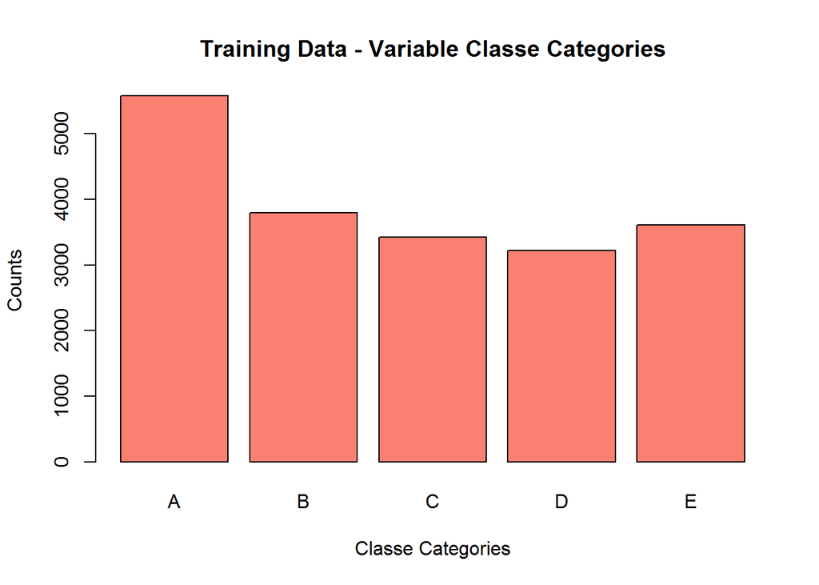

```r
plot(train_data$classe, col="salmon", xlab = "Classe Categories", ylab = "Counts", main = "Training Data - Variable Classe Categories")
```

# Prediction Model

### Cross Validation Strategy

We will be further splitting the training data into 2 subset:

- 75% - train_sub
- 25% - test_sub

```r
train_Parts <- createDataPartition(train_data$classe, p = .75, list = FALSE)
train_sub <- train_data[train_Parts,]
test_sub  <- train_data[-train_Parts,]
```

| Data | Rows | Columns |
| --- | --- | --- |
| Training Data | 19622 | 53 |
| -> Train_sub | 14718 | 53 |
| -> Test_sub | 4904 | 53 |
| Test Data | 20 | 53 |

### Prediction Model Selection

We will be considering 2 prediction models.

- Prediction Trees
- Random Forest

**1. Prediction Trees**

```r
tree_model <- train(classe ~ ., data = train_sub, method="rpart")
tree_predict <- predict(tree_model,test_sub)
treeP_M <- confusionMatrix(tree_predict, test_sub$classe)
treeP_M
```

```
## Confusion Matrix and Statistics
##
##           Reference
## Prediction    A    B    C    D    E
##          A 1277  400  395  373  136
##          B   21  331   28  131  118
##          C   92  218  432  300  249
##          D    0    0    0    0    0
##          E    5    0    0    0  398
##
## Overall Statistics
##
##                Accuracy : 0.4971
##                  95% CI : (0.4831, 0.5112)
##     No Information Rate : 0.2845
##     P-Value [Acc > NIR] : < 0.00000000000000022
##
##                   Kappa : 0.3422
##  Mcnemar's Test P-Value : NA
##
## Statistics by Class:
##
##                      Class: A Class: B Class: C Class: D Class: E
## Sensitivity            0.9154   0.3488  0.50526   0.0000  0.44173
## Specificity            0.6284   0.9247  0.78785   1.0000  0.99875
## Pos Pred Value         0.4948   0.5262  0.33462      NaN  0.98759
## Neg Pred Value         0.9492   0.8554  0.88292   0.8361  0.88825
## Prevalence             0.2845   0.1935  0.17435   0.1639  0.18373
## Detection Rate         0.2604   0.0675  0.08809   0.0000  0.08116
## Detection Prevalence   0.5263   0.1283  0.26325   0.0000  0.08218
## Balanced Accuracy      0.7719   0.6367  0.64656   0.5000  0.72024
```

Getting the Out of Sample Error

```r
len_predictTree <- length(tree_predict)
outOfSampleErrorTree.acc <- sum(tree_predict == test_sub$classe)/len_predictTree
outOfSampleErrorTree <- (1 - outOfSampleErrorTree.acc) * 100
```

**2. Random Forest**

```r
forest_model <- randomForest(classe ~. , data= train_sub, method="class")
forest_predict <- predict(forest_model, test_sub)
randomF_M <- confusionMatrix(forest_predict, test_sub$classe)
randomF_M
```

```
## Confusion Matrix and Statistics
##
##           Reference
## Prediction    A    B    C    D    E
##          A 1393    4    0    0    0
##          B    2  941    1    0    0
##          C    0    4  854    5    0
##          D    0    0    0  799    1
##          E    0    0    0    0  900
##
## Overall Statistics
##
##                Accuracy : 0.9965
##                  95% CI : (0.9945, 0.998)
##     No Information Rate : 0.2845
##     P-Value [Acc > NIR] : < 0.00000000000000022
##
##                   Kappa : 0.9956
##  Mcnemar's Test P-Value : NA
##
## Statistics by Class:
##
##                      Class: A Class: B Class: C Class: D Class: E
## Sensitivity            0.9986   0.9916   0.9988   0.9938   0.9989
## Specificity            0.9989   0.9992   0.9978   0.9998   1.0000
## Pos Pred Value         0.9971   0.9968   0.9896   0.9988   1.0000
## Neg Pred Value         0.9994   0.9980   0.9998   0.9988   0.9998
## Prevalence             0.2845   0.1935   0.1743   0.1639   0.1837
## Detection Rate         0.2841   0.1919   0.1741   0.1629   0.1835
## Detection Prevalence   0.2849   0.1925   0.1760   0.1631   0.1835
## Balanced Accuracy      0.9987   0.9954   0.9983   0.9968   0.9994
```

Getting the Out of Sample Error

```r
len_predictForest <- length(forest_predict)
outOfSampleErrorForest.acc <- sum(forest_predict == test_sub$classe)/len_predictForest
outOfSampleErrorForest <- (1 - outOfSampleErrorForest.acc) * 100
```

### The Final Verdict

| Prediction Model | Accuracy | 95% CI | Out of Sample Error (%) |
| --- | --- | --- | --- |
| Decision Trees | 0.4971452 | 0.4830546, 0.5112391 | 50.2854812 |
| Random Forest | 0.9965334 | 0.9944555, 0.9979793 | 0.3466558 |

As we can see from the results of the confusion matrix, the Random Forest model has the highest accuracy with 0.9965334 and a 95% CI between [0.9944555, 0.9979793]. It also has the lowest out of sample error 0.3466558% compared to Decision Trees Model

## Applying Prediction Model to the test data

Using the final prediction model, we would be able to perform prediction on the testing data sourced from https://d396qusza40orc.cloudfront.net/predmachlearn/pml-testing.csv)

```r
final_predict <- predict(forest_model, test_data)
final_predict
```

```
##  1  2  3  4  5  6  7  8  9 10 11 12 13 14 15 16 17 18 19 20
##  B  A  B  A  A  E  D  B  A  A  B  C  B  A  E  E  A  B  B  B
## Levels: A B C D E
```